# CSSS 508, Week 11: Tidy Model Results and Applied Data Cleaning

Charles Lanfear  
May 30th, 2018

### Topics for Today

Displaying Model Results

- `broom`
  - Turning model output lists into dataframes
  - Summarizing models
- `ggeffects`
  - Creating predicted values
  - Plotting marginal effects
- Making regression tables
  - Using `pander` for models
  - Using `sjTable()` in `sjPlot`
- Advanced data manipulation example
- Wrapping up the course

## broom

### broom

`broom` is a package that “tidies up” the output from models such a `lm()` and `glm()`.

It has a small number of key functions:

- `tidy()` - Creates a dataframe summary of a model.
- `augment()` - Adds columns—such as fitted values—to the data used in the model.
- `glance()` - Provides one row of fit statistics for models.

```r
library(broom)
```

### Standard Output is Lists

`lm()` and `summary()` produce lists as output, which cannot go directly into tidyverse functions, particularly those in `ggplot2`.

```r
data(mtcars)
lm_1 <- lm(mpg~wt+hp, data=mtcars)
summary(lm_1)
```

```
Call:
lm(formula = mpg ~ wt + hp, data = mtcars)

Residuals:
   Min     1Q Median     3Q    Max
-3.941 -1.600 -0.182  1.050  5.854

Coefficients:
            Estimate Std. Error t value Pr(>|t|)
(Intercept) 37.22727    1.59879  23.285  < 2e-16 ***
wt          -3.87783    0.63273  -6.129 1.12e-06 ***
hp          -0.03177    0.00903  -3.519  0.00145 **
---
Signif. codes:  0 '***' 0.001 '**' 0.01 '*' 0.05 '.' 0.1 ' ' 1

Residual standard error: 2.593 on 29 degrees of freedom
Multiple R-squared:  0.8268,    Adjusted R-squared:  0.8148
F-statistic: 69.21 on 2 and 29 DF,  p-value: 9.109e-12
```

### Standard Output Varies!

Each type of model also produces somewhat different output, so you can't just reuse the same code to handle output from every model.

```r
glm_1 <- glm(am~hp+wt, data=mtcars, family=binomial(link="logit"))
summary(glm_1)
```

```
Call:
glm(formula = am ~ hp + wt, family = binomial(link = "logit"),
    data = mtcars)

Deviance Residuals:
    Min       1Q   Median       3Q      Max
-2.2537  -0.1568  -0.0168   0.1543   1.3449

Coefficients:
            Estimate Std. Error z value Pr(>|z|)
(Intercept) 18.86630    7.44356   2.535  0.01126 *
hp           0.03626    0.01773   2.044  0.04091 *
wt          -8.08348    3.06868  -2.634  0.00843 **
---
Signif. codes:  0 '***' 0.001 '**' 0.01 '*' 0.05 '.' 0.1 ' ' 1

(Dispersion parameter for binomial family taken to be 1)

    Null deviance: 43.230  on 31  degrees of freedom
Residual deviance: 10.059  on 29  degrees of freedom
AIC: 16.059

Number of Fisher Scoring iterations: 8
```

### broom tidy()

`tidy()` produces the same output, but as a dataframe.

```r
lm_1 %>% tidy()
```

```
         term    estimate  std.error statistic      p.value
1 (Intercept) 37.22727012 1.59878754 23.284689 2.565459e-20
2          wt -3.87783074 0.63273349 -6.128695 1.119647e-06
3          hp -0.03177295 0.00902971 -3.518712 1.451229e-03
```

### broom tidy()

```r
glm_1 %>% tidy()
```

```
         term   estimate  std.error statistic     p.value
1 (Intercept) 18.8662987 7.44355806  2.534581 0.011258199
2          hp  0.0362556 0.01773415  2.044394 0.040914646
3          wt -8.0834752 3.06867511 -2.634191 0.008433813
```

### broom glance()

`glance()` produces dataframes of fit statistics for models. If you run many models, you can compare each model row-by-row in each column… or even plot their different fit statistics to allow holistic comparison.

```r
glance(lm_1)
```

```
  r.squared adj.r.squared    sigma statistic      p.value df    logLik
1 0.8267855     0.8148396 2.593412  69.21121 9.109054e-12  3 -74.32617
       AIC      BIC deviance df.residual
1 156.6523 162.5153 195.0478          29
```

### broom augment()

`augment()` takes values generated by a model and adds them back to the original data. This includes fitted values, residuals, and leverage statistics.

```r
augment(lm_1) %>% head()
```

```
          .rownames  mpg    wt  hp  .fitted   .se.fit     .resid
1         Mazda RX4 21.0 2.620 110 23.57233 0.5457078 -2.5723294
2     Mazda RX4 Wag 21.0 2.875 110 22.58348 0.5218283 -1.5834826
3        Datsun 710 22.8 2.320  93 25.27582 0.6363166 -2.4758187
4    Hornet 4 Drive 21.4 3.215 110 21.26502 0.5650719  0.1349799
5 Hornet Sportabout 18.7 3.440 175 18.32727 0.4979275  0.3727334
6           Valiant 18.1 3.460 105 20.47382 0.6720442 -2.3738163
        .hat   .sigma      .cooksd .std.resid
1 0.04427691 2.592051 1.589652e-02 -1.0145865
2 0.04048669 2.621576 5.464779e-03 -0.6233275
3 0.06020097 2.594812 2.070651e-02 -0.9847588
4 0.04747494 2.639187 4.724822e-05  0.0533285
5 0.03686288 2.638340 2.736184e-04  0.1464478
6 0.06715104 2.598125 2.155064e-02 -0.9476980
```

### The Power of broom

The real advantage of `broom` becomes apparent when running many models at once. Here we run separate models for each level of `cyl`:

```r
mtcars %>% group_by(cyl) %>%
  do(tidy(lm(mpg ~  wt + hp + disp, data=.)))
```

```
# A tibble: 12 x 6
# Groups:   cyl [3]
     cyl term            estimate std.error  statistic   p.value
   <dbl> <chr>              <dbl>     <dbl>      <dbl>     <dbl>
 1    4. (Intercept)  44.9           5.03    8.92      0.0000452
 2    4. wt           -2.59          3.52   -0.735     0.486
 3    4. hp           -0.0645        0.0549 -1.18      0.278
 4    4. disp         -0.0663        0.0818 -0.810     0.445
 5    6. (Intercept)  30.3           5.63    5.38      0.0126
 6    6. wt           -3.90          1.41   -2.75      0.0705
 7    6. hp           -0.0110        0.0213 -0.514     0.643
 8    6. disp          0.0161        0.0135  1.20      0.317
 9    8. (Intercept)  26.7           3.91    6.82      0.0000461
10    8. wt           -2.18          1.16   -1.88      0.0902
11    8. hp           -0.0137        0.0114 -1.20      0.258
12    8. disp          0.00000110    0.0131  0.0000843 1.000
```

## ggeffects

### ggeffects

While `broom` produces tidy model *summaries*, `ggeffects` is used to create tidy *marginal effects*. That is, tidy dataframes of *ranges* of predicted values that can be fed straight into `ggplot2` for plotting model results.

- `ggpredict()` - Computes predicted values for the outcome variable at margins of specific variables.
- `plot.ggeffects()` - A plot method for `ggeffects` objects (like `ggredict()` output)

```r
library(ggeffects)
```

### ggpredict()

When you run `ggpredict()`, it produces a dataframe with a row for every unique value of a supplied predictor (“independent”) variable (`term`). Each row contains a predicted value for the outcome (“dependent”) variable, plus confidence intervals. The argument `interval="prediction"` will give predicted intervals instead.

```r
(lm_1_predicted <- ggpredict(lm_1, terms="wt"))
```

```
# A tibble: 29 x 5
       x predicted conf.low conf.high group
   <dbl>     <dbl>    <dbl>     <dbl> <fct>
 1  1.51      26.7     24.4      29.0 1
 2  1.62      26.3     24.1      28.5 1
 3  1.84      25.5     23.5      27.4 1
 4  1.94      25.1     23.2      26.9 1
 5  2.14      24.3     22.7      25.9 1
 6  2.20      24.0     22.5      25.6 1
 7  2.32      23.6     22.1      25.0 1
 8  2.46      23.0     21.7      24.3 1
 9  2.62      22.4     21.2      23.6 1
10  2.77      21.8     20.8      22.9 1
# ... with 19 more rows
```

### plot() for ggpredict()

`ggeffects` features a `plot()` *method* (`plot.ggeffects()`), which automatically produces a ggplot when you give `plot()` an object created by a `ggeffects` function.

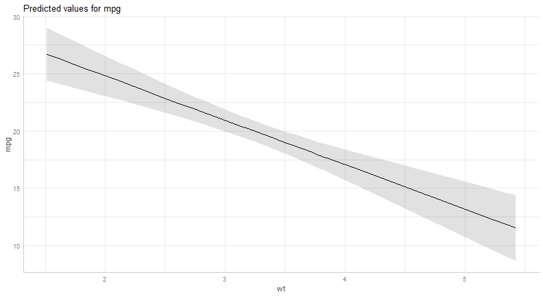

```r
plot(lm_1_predicted)
```

### Grouping with ggpredict()

When using a vector of multiple `terms`, `ggeffects` will plot the first along the x-axis and use subsequent terms for *grouping*. Note we can pipe a model straight into `ggpredict()`!

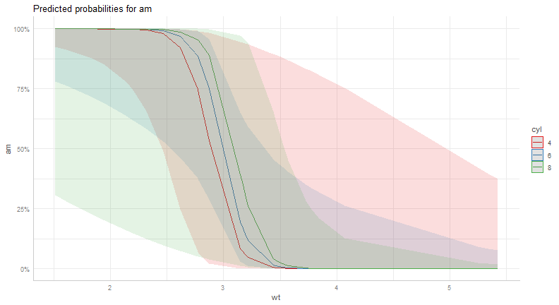

```r
glm(am ~ hp + wt + cyl, data=mtcars, family=binomial(link="logit")) %>%
  ggpredict(terms=c("wt", "cyl")) %>% plot()
```

### Faceting with ggpredict()

You can add `facet=TRUE` to the `plot()` call to facet over *grouping terms*.

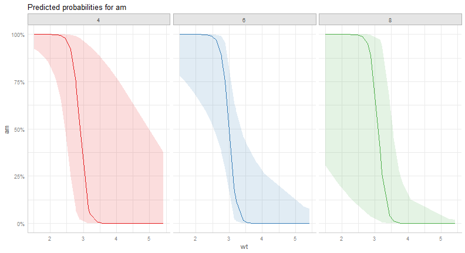

```r
glm(am ~ hp + wt + cyl, data=mtcars, family=binomial(link="logit")) %>%
  ggpredict(terms=c("wt", "cyl")) %>% plot(facet=TRUE)
```

### Setting Counterfactual Values with ggpredict()

You can add values in square brackets in the `terms=` argument to specify counterfactual values.

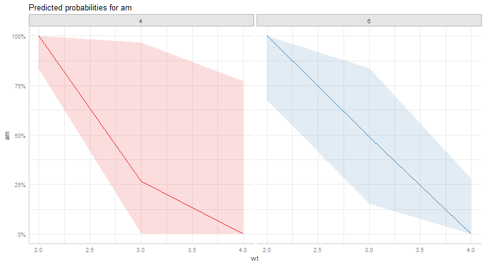

```r
glm(am ~ hp + wt + cyl, data=mtcars, family=binomial(link="logit")) %>%
  ggpredict(terms=c("wt [2,3,4]", "cyl [4,6]")) %>% plot(facet=TRUE)
```

### Dot plots with ggpredict

`ggpredict` will produce dot plots with error bars for categorical predictors.

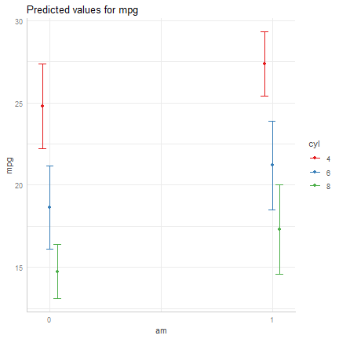

```r
lm(mpg~as.factor(am)+as.factor(cyl), data=mtcars) %>% ggpredict(terms=c("am", "cyl")) %>% plot()
```

### Notes on ggeffects

There is a lot more to the `ggeffects` package that you can see in [the package vignette](https://cran.r-project.org/web/packages/ggeffects/vignettes/marginaleffects.html) and the [github repository](https://github.com/strengejacke/ggeffects). This includes, but is not limited to:

- Setting specific counterfactual values of covariates
- Predicted values for polynomial and interaction terms
- Getting predictions from models from dozens of other packages
- Sending `ggeffects` objects to `ggplot2` to freely modify plots

## Making Tables

### Regression Tables with Pander

We've used `pander` to create nice tables for dataframes. But `pander` has *methods* to handle all sort of objects that you might want displayed nicely. This includes model output, such as from `lm()`, `glm()`, and `summary()`.

```r
library(pander)
```

### Pander and lm

You can send an `lm()` object straight to `pander`:

```r
pander(lm_1)
```

|  | Estimate | Std. Error | t value | Pr(>t) |
| --- | --- | --- | --- | --- |
| **(Intercept)** | 37.23 | 1.599 | 23.28 | 2.565e-20 |
| **wt** | -3.878 | 0.6327 | -6.129 | 1.12e-06 |
| **hp** | -0.03177 | 0.00903 | -3.519 | 0.001451 |

Table: Fitting linear model: mpg ~ wt + hp

### Pander and summary

You can do this with `summary()` as well, for added information:

```r
pander(summary(lm_1))
```

|  | Estimate | Std. Error | t value | Pr(>t) |
| --- | --- | --- | --- | --- |
| **(Intercept)** | 37.23 | 1.599 | 23.28 | 2.565e-20 |
| **wt** | -3.878 | 0.6327 | -6.129 | 1.12e-06 |
| **hp** | -0.03177 | 0.00903 | -3.519 | 0.001451 |

| Observations | Residual Std. Error | \( R^2 \) | Adjusted \( R^2 \) |
| --- | --- | --- | --- |
| 32 | 2.593 | 0.8268 | 0.8148 |

Table: Fitting linear model: mpg ~ wt + hp

### sjPlot

`pander` tables are great for `rmarkdown` documents or webpages, but they're not generally publication ready. The `sjPlot` package produces tables that look more like those you may find in journal articles.

```r
library(sjPlot)
```

### sjPlot Tables

`sjt.lm()` will produce attractive plots for `lm()` objects. `sjt.glm()` handles `glm()` models.

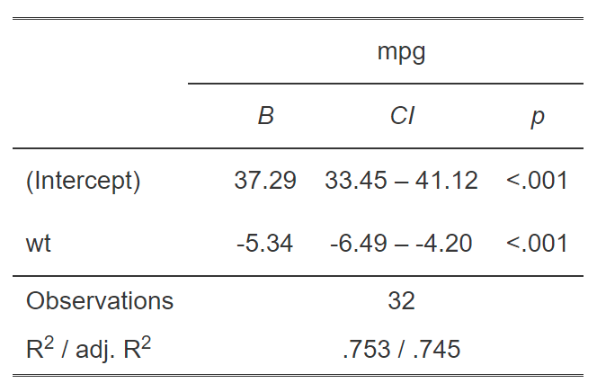

```r
model_1 <- lm(mpg ~ wt, data = mtcars)
sjt.lm(model_1)
```

### Multi-Model Tables with sjTable

Often in journal articles you will see a single table that compares multiple models. Typically, authors will start with a simple model on the left, then add variables, until they have their most complex model on the right. The `sjPlot` package makes this easy to do: just give it more models!

### sjTable with Multiple Models

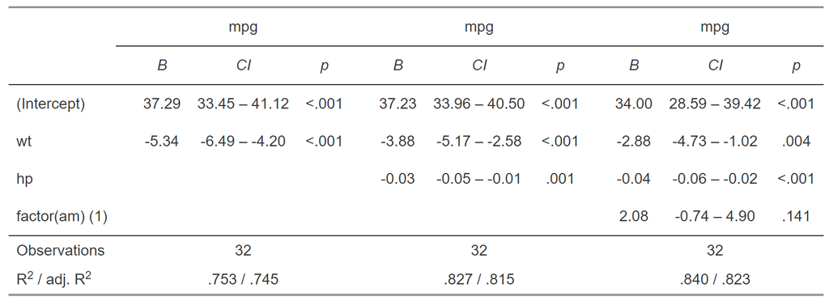

```r
model_2 <- lm(mpg ~ hp + wt, data = mtcars)
model_3 <- lm(mpg ~ hp + wt + factor(am), data = mtcars)
sjt.lm(model_1, model_2, model_3)
```

### sjPlot does a lot more

The sjPlot package does *a lot* more than just make pretty tables. It is a rabbit hole of *incredibly* powerful and useful functions for displaying descriptive and inferential results.

View the [package website](http://www.strengejacke.de/sjPlot/) for extensive documentation.

`sjPlot` is a bit more complicated than `ggeffects` but can do just about everything it can do; they were written by the same author!

`sjPlot` is fairly new but may be poised to be a comprehensive solution for `ggplot` based publication-ready social science data visualization. All graphical functions in `sjPlot` are based on `ggplot2`, so it should not take terribly long to figure out.

### sjPlot Example: Likert scale plots

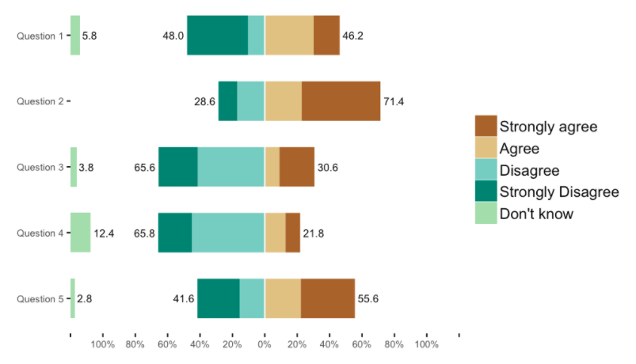

### sjPlot Example: Crosstabs

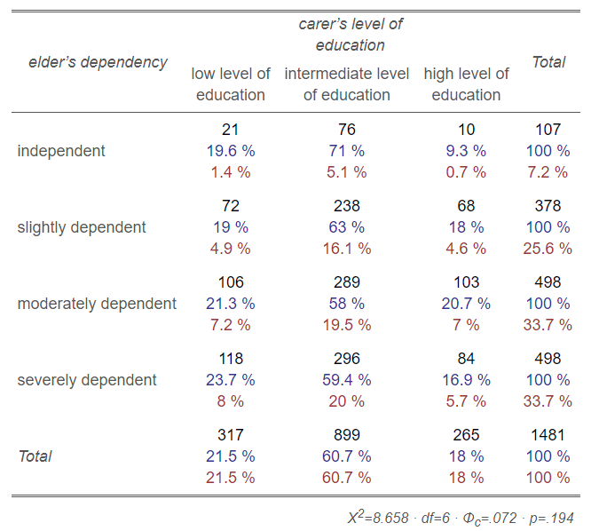

### LaTeX Tables in Theses / Dissertations / Posters

For tables in \( \LaTeX \) documents, which are common for theses, dissertations, and posters, I recommend either manually generating tables or looking into the `stargazer` or `kableExtra` packages.

`kableExtra` allows the construction of complex tables in either HTML or \( \LaTeX \) using additive syntax similar to `ggplot2`.

`stargazer` produces nicely formatted \( \LaTeX \) tables but is fussy and idiosyncratic.

If you want to edit \( \LaTeX \) documents, you can do it in R using Sweave documents (.Rnw). Alternatively, you may want to work in a dedicated LaTeX editor. I recommend [Overleaf](http://www.overleaf.com) for this purpose.

RMarkdown has support for a fair amount of basic \( \LaTeX \) syntax if you aren't trying to get too fancy!

Another approach I have used is to manually format \( \LaTeX \) tables but use in-line R calls to fill in the values dynamically. This gets you the *exact* format you want but without forcing you to update values any time something changes.

### Bonus: corrplot

The `corrplot` package has functions for displaying correlograms.

These make visualizing the correlations between variables in a data set easier.

The first argument is a call to `cor()`, the base R function for generating a correlation matrix.

[See the vignette for customization options.](https://cran.r-project.org/web/packages/corrplot/vignettes/corrplot-intro.html)

```r
library(corrplot)
corrplot(
  cor(mtcars),
  addCoef.col = "white",
  addCoefasPercent=T,
  type="upper",
  order="AOE")
```

## Correlogram

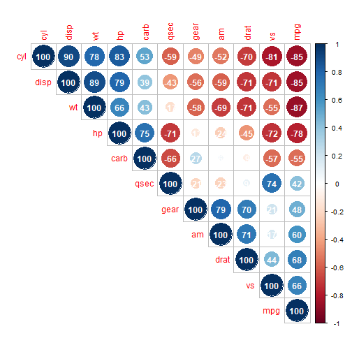

## Advanced Data Manipulation

This section walks you through an example of a real-world data management scenario.

We will use a small extract from the **Denver Youth Survey**, a 10-wave (in this example) panel data set with 1526 respondents aged 7 to 26.

### Example Data

```r
load("mar_ages.RData") # Tiny sample of my real data
mar_ages
```

```
   seqid  byr marriage_n marriage_age divorce_age censored_age
1      1 1978          1           NA          NA           20
2      1 1978          2           NA          NA           20
3      1 1978          3           NA          NA           20
4      2 1974          1           23          NA           24
5      2 1974          2           NA          NA           24
6      2 1974          3           NA          NA           24
7     10 1976          1           15          19           22
8     10 1976          2           NA          NA           22
9     10 1976          3           NA          NA           22
10    18 1976          1           17          18           22
11    18 1976          2           NA          NA           22
12    18 1976          3           NA          NA           22
13   280 1974          1           18          24           24
14   280 1974          2           24          NA           24
15   280 1974          3           NA          NA           24
16   417 1972          1           18          22           26
17   417 1972          2           23          24           26
18   417 1972          3           25          NA           26
```

### Structure of the Data

These data are in “long” format where each individual has multiple observations. Our “time” is in *age* rather than years and our observations are *person-marriages*.

Variables:

- **seqid** - Individual identifier
- **byr** - Birth year
- **marriage_n** - Marriage number (most never married or once)
- **marriage_age** - If married, the age at which they married
- **divorce_age** - If divorced, the age at which they divorced
- **censored_age** - Last age they were observed in data

### The Goal

How are we going to do this?

### Some Comments

I like to type out long comments that describe my problem and possible strategies!

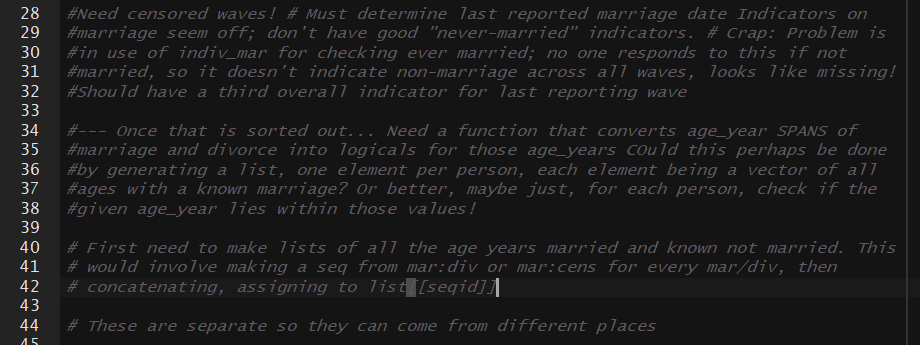

If interested, [here is a link to my *unedited script* this is all taken from.](https://raw.githubusercontent.com/clanfear/CSSS508/master/Lectures/Week11/marriage_dates_to_age_year_110317.R) It is a bit messy, long, and inefficient but is a realistic example of “in-use” code. Note that it assumes access to the full data set, which I cannot share.

### Strategy

There are many ways to approach this problem, but this was the strategy I came up with:

1. Get the ages in which individuals were known to be married.
   - If married once and never divorced, this is all ages from `marriage_age` to `censored_age`
   - If divorced, it is from `marriage_age` to `divorce_age`.
   - Multiple marriages are just more of the above.
2. Get the ages in which individuals were known to be not married.
   - If never married, they were not married up until `censored_age`.
   - If married and divorced, they were not married until `marriage_age` and after `divorce_age`, until another marriage.
3. What remains is the unknown or missing ages.
4. Make a matrix of individuals (rows) and ages (columns) and populate the cells using 1, 2, and 3.

### Coding Married Ages 1

First, get a **list** where each **element** is a **vector** of married ages for *each marriage*.

```r
married_years <- vector("list", nrow(mar_ages))
names(married_years) <- paste0(mar_ages$seqid, "-", mar_ages$marriage_n)
for (i in 1:nrow(mar_ages)){
  if (is.na(mar_ages$marriage_age[i])){
    married_years[[i]] <- NA # Assign NA if no marriage
  } else if (!is.na(mar_ages$marriage_age[i]) & # Was married...
              is.na(mar_ages$divorce_age[i])) { # but not divorced
      if (mar_ages$marriage_age[i] <= mar_ages$censored_age[i]){
         married_years[[i]] <- # Marriage age to censored age
           mar_ages$marriage_age[i]:mar_ages$censored_age[i]
      } else { # If married for only one year
         married_years[[i]] <- mar_ages$marriage_age[i]
      }
  } else if (!is.na(mar_ages$marriage_age[i]) & # Married...
             !is.na(mar_ages$divorce_age[i])) { # ... and divorced
    married_years[[i]] <- # Marriage age to divorce age
      mar_ages$marriage_age[i]:mar_ages$divorce_age[i]
  } else { # Print ERROR if none of above conditions apply
    married_years[[i]] <- "ERROR"; print(paste0("Error on ", i))
  }}
```

### Coding Married Ages 2

```r
head(married_years)
```

```
$`1-1`
[1] NA

$`1-2`
[1] NA

$`1-3`
[1] NA

$`2-1`
[1] 23 24

$`2-2`
[1] NA

$`2-3`
[1] NA
```

### Coding Married Ages 3

Next, *combine* each person's *three vectors* into *one vector* of married ages.

```r
age_year_yes_list <- vector("list", length(unique(mar_ages$seqid)))
names(age_year_yes_list) <- paste0("seqid_", unique(mar_ages$seqid))
for (i in 1:length(age_year_yes_list)){
  vals <- c(married_years[[(3*i)-2]],
            married_years[[(3*i)-1]],
            married_years[[(3*i)]])
  if (all(is.na(vals))) {
    age_year_yes_list[[i]] <- NA # NA if all values are NA
  } else { # Otherwise, assign non-NA values
  age_year_yes_list[[i]] <- unique(vals[!is.na(vals)])
  }
}
```

### Coding Married Ages 4

```r
head(age_year_yes_list)
```

```
$seqid_1
[1] NA

$seqid_2
[1] 23 24

$seqid_10
[1] 15 16 17 18 19

$seqid_18
[1] 17 18

$seqid_280
[1] 18 19 20 21 22 23 24

$seqid_417
[1] 18 19 20 21 22 23 24 25 26
```

### Coding Unmarried Ages 1

Similar to the married code, but now I assume no one was married at age 10 and work from there up.

```r
unmarried_years <- vector("list", nrow(mar_ages))
names(unmarried_years) <- paste0(mar_ages$seqid, "-", mar_ages$marriage_n)
for (i in 1:nrow(mar_ages)){
  if (is.na(mar_ages$censored_age[i])) {
    unmarried_years[[i]] <- NA # NA if always censored
  } else if (is.na(mar_ages$marriage_age[i])) { # If never married
    unmarried_years[[i]] <- 10:mar_ages$censored_age[i]
  } else if (!is.na(mar_ages$marriage_age[i]) & # Married...
              is.na(mar_ages$divorce_age[i])){ # ... without divorce
    unmarried_years[[i]] <- 10:mar_ages$marriage_age[i]
  } else if (!is.na(mar_ages$marriage_age[i]) & # Married...
             !is.na(mar_ages$divorce_age[i])) { # ... and divorced
    unmarried_years[[i]] <- c(10:mar_ages$marriage_age[i],
            mar_ages$divorce_age[i]:mar_ages$censored_age[i])
  } else {
    unmarried_years[[i]] <- "ERROR"; print(paste0("Error on ", i))
  }
}
```

### Coding Unarried Ages 2

```r
head(unmarried_years)
```

```
$`1-1`
 [1] 10 11 12 13 14 15 16 17 18 19 20

$`1-2`
 [1] 10 11 12 13 14 15 16 17 18 19 20

$`1-3`
 [1] 10 11 12 13 14 15 16 17 18 19 20

$`2-1`
 [1] 10 11 12 13 14 15 16 17 18 19 20 21 22 23

$`2-2`
 [1] 10 11 12 13 14 15 16 17 18 19 20 21 22 23 24

$`2-3`
 [1] 10 11 12 13 14 15 16 17 18 19 20 21 22 23 24
```

### Coding Unmarried Ages 3

Combine all unmarried ages into a single vector per person.

```r
age_year_no_list <- vector("list", length(unique(mar_ages$seqid)))
names(age_year_no_list) <- paste0("seqid_", unique(mar_ages$seqid))
for (i in 1:length(age_year_no_list)){
  vals <- c(unmarried_years[[(3*i)-2]],
            unmarried_years[[(3*i)-1]],
            unmarried_years[[(3*i)]])
  if (all(is.na(vals))) {
    age_year_no_list[[i]] <- NA
  } else {
    age_year_no_list[[i]] <- unique(vals[!is.na(vals)])
    age_year_no_list[[i]] <-
      age_year_no_list[[i]][age_year_no_list[[i]] %!in%
                              age_year_yes_list[[i]]]
  }
}
```

### Coding Unmarried Ages 4

```r
head(age_year_no_list)
```

```
$seqid_1
 [1] 10 11 12 13 14 15 16 17 18 19 20

$seqid_2
 [1] 10 11 12 13 14 15 16 17 18 19 20 21 22

$seqid_10
[1] 10 11 12 13 14 20 21 22

$seqid_18
 [1] 10 11 12 13 14 15 16 19 20 21 22

$seqid_280
[1] 10 11 12 13 14 15 16 17

$seqid_417
[1] 10 11 12 13 14 15 16 17
```

### A Function to Convert from Lists to a Matrix

```r
ay_list_to_ay_mat <- function(age_year_yes_list, age_year_no_list){
  age_year_mat <- setNames(as.data.frame(matrix(as.numeric(NA),
              ncol=length(10:27), nrow=6)), paste0("age_", 10:27))
  for(i in 1:6){ # Six individuals!
    if (any(!is.na(age_year_yes_list[[i]]))){
      age_year_mat[i, age_year_yes_list[[i]]-9 ] <- 1
    } # Above: If any married ages, assign 1 to corresponding cells
    if (any(!is.na(age_year_no_list[[i]]))){
      age_year_mat[i, age_year_no_list[[i]]-9 ] <- 0
    } # Above: If any unmarried ages, assign 1 to corresponding cells
  }
  return(age_year_mat)
}

mar_age_year_mat <-
  ay_list_to_ay_mat(age_year_yes_list = age_year_yes_list,
                    age_year_no_list = age_year_no_list)
mar_age_year_mat <- mar_age_year_mat %>%
  mutate(seqid=c(1,2,10,18,280,417)) %>%
  select(seqid, starts_with("age"), -age_27)
```

### What Did We get?

```r
mar_age_year_mat %>% select(seqid, age_10:age_17)
```

```
  seqid age_10 age_11 age_12 age_13 age_14 age_15 age_16 age_17
1     1      0      0      0      0      0      0      0      0
2     2      0      0      0      0      0      0      0      0
3    10      0      0      0      0      0      1      1      1
4    18      0      0      0      0      0      0      0      1
5   280      0      0      0      0      0      0      0      0
6   417      0      0      0      0      0      0      0      0
```

```r
mar_age_year_mat %>% select(seqid, age_18:age_25)
```

```
  seqid age_18 age_19 age_20 age_21 age_22 age_23 age_24 age_25
1     1      0      0      0     NA     NA     NA     NA     NA
2     2      0      0      0      0      0      1      1     NA
3    10      1      1      0      0      0     NA     NA     NA
4    18      1      0      0      0      0     NA     NA     NA
5   280      1      1      1      1      1      1      1     NA
6   417      1      1      1      1      1      1      1      1
```

### Conclusion

Data wrangling can be very complicated, with many valid ways of accomplishing it.

I believe the best general approach is the following:

1. Look carefully at the **starting data** to figure out what you can get from them.
2. Determine *precisely* what you want the **end product** to look like.
3. Identify individual steps needed to go from Step 1 to Step 2.
4. Make each discrete step its own set of functions or function calls.
   - If any step is confusing or complicated, **break it into more steps**.
5. Complete each step *separately and in order*.
   - Do not continue until a step is producing what you need for the next step.
   - **Do not worry about combining steps for efficiency until everything works**.

Once finished, if you need to do this again, *convert the prior steps into functions*!

## Wrapping up the Course

### What You've Learned

A lot!

- How to get data into R from a variety of formats
- How to do “data custodian” work to manipulate and clean data
- How to make pretty visualizations
- How to automate with loops and functions
- How to combine text, calculations, plots, and tables into dynamic R Markdown reports
- How to acquire and work with spatial data

### What Comes Next?

- Statistical inference (e.g. more CSSS courses)
  - Functions for hypothesis testing, hierarchical/mixed effect models, machine learning, survey design, etc. are straightforward to use… once data are clean
  - Access output by working with list structures (like from regression models) or using `broom` and `ggeffects`
- Practice, practice, practice!
  - Replicate analyses you've done in Excel, SPSS, or Stata
  - Think about data using `dplyr` verbs, tidy data principles
  - R Markdown for documenting cleaning and analysis start-to-finish
- More advanced projects
  - Using version control (git) in RStudio
  - Interactive Shiny web apps
  - Write your own functions and put them in a package

### Course Plugs

If you…

- have no stats background yet - **SOC504: Applied Social Statistics**
- want to learn more social science computing - **SOC590: Big Data and Population Processes**
- have (only) finished SOC506 - **CSSS510: Maximum Likelihood**
- want to master visualization - **CSSS569: Visualizing Data**
- study events or durations - **CSSS544: Event History Analysis**
- want to use network data - **CSSS567: Social Network Analysis**
- want to work with spatial data - **CSSS554: Spatial Statistics**